# Occupant Responsive Buildings (ORBs)

## Contents

1. Contents
2. Background
3. Demonstration
4. Approach
   1. WiFi Connections
   2. Change Point Detection
5. Endpoints
   1. Analysis
   2. Prediction
6. Download
7. Creators

## Background

Irreversible climate change is occurring due to energy and natural resource usage trends. Facilities/energy managers need a tool to maximize availability while minimizing consumption based on vacancy patterns in buildings.

With the onset of the COVID-19 pandemic, buildings at Lawrence Berkeley National Labs saw occupancy levels drop by 90%, yet energy usage only dropped 20% due to buildings waking up and being put to sleep on pre-pandemic schedules.

[figure not shown]

## Demonstration

```python
IFrame('https://drive.google.com/file/d/1qQNcaaOFir60h_YrSG7H8Xw2MTUD4j1n/preview', width=640, height=480)
```

[interactive chart not shown]

## Approach

### WiFi Connections

For success in its aims, ORB must be readily accessible to and useful for facilities managers in as large a number and variety of buildings as possible. While buildings can vary in the number and types of sensors they have installed, aggregated WiFi connection data (i.e. a count of the number of devices connected to WiFi in the building) is ubiquitous and easy-to-access in most buildings. As such, we use WiFi data as a route to determining building occupancy:

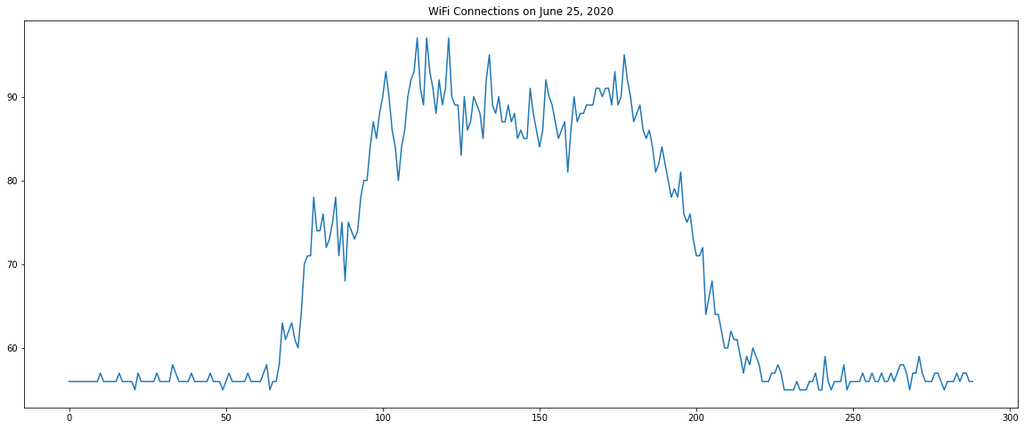

### Change Point Detection

Well-established change point detection methods exist to identify large shifts in time series data, such as this aggregated WiFi connection data. In particular, the [ruptures](https://centre-borelli.github.io/ruptures-docs/) Python package simplifies the usage of several of these methods on numpy arrays. The 11 methods outlined below work particularly well to identify two change points in a single day (i.e. start of day and end of day).

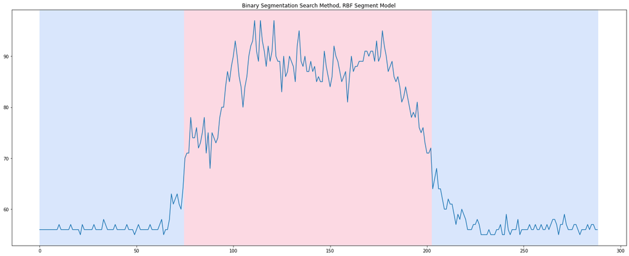

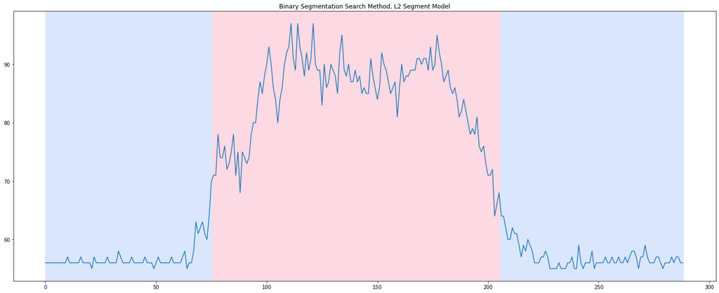

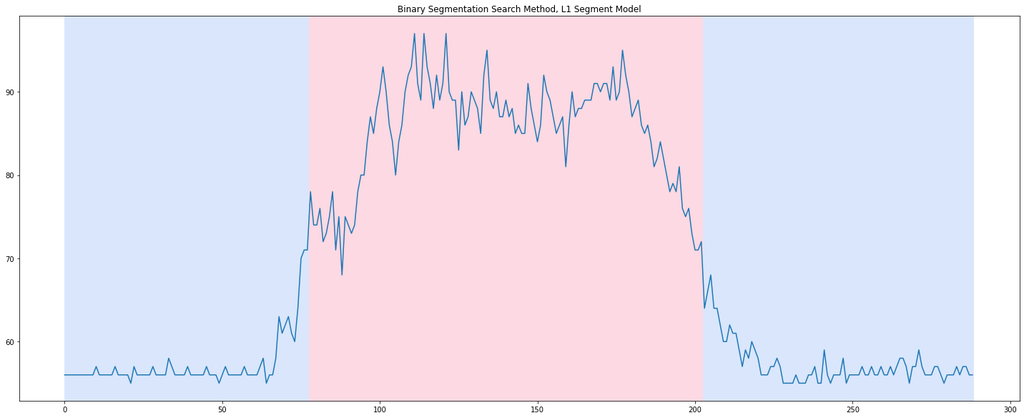

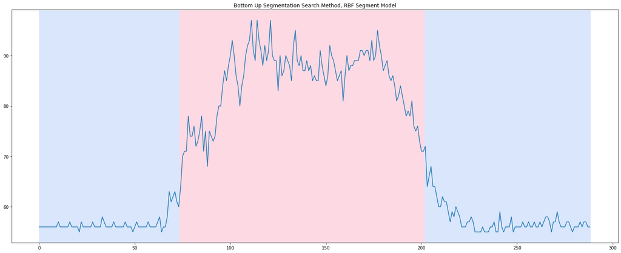

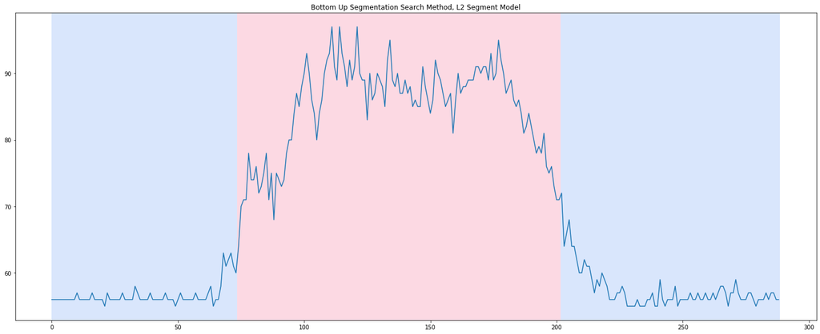

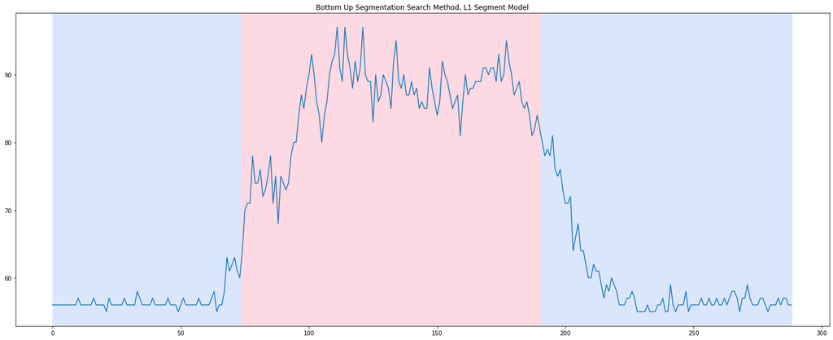

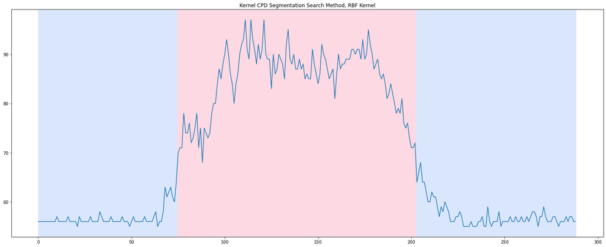

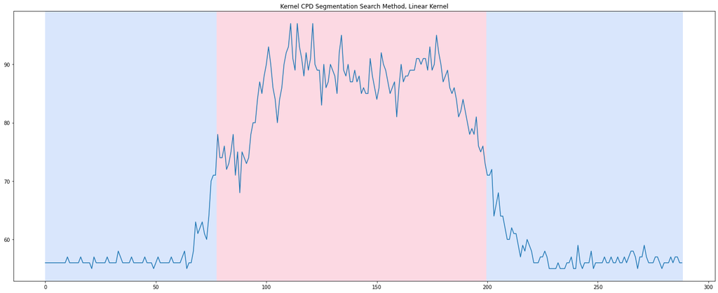

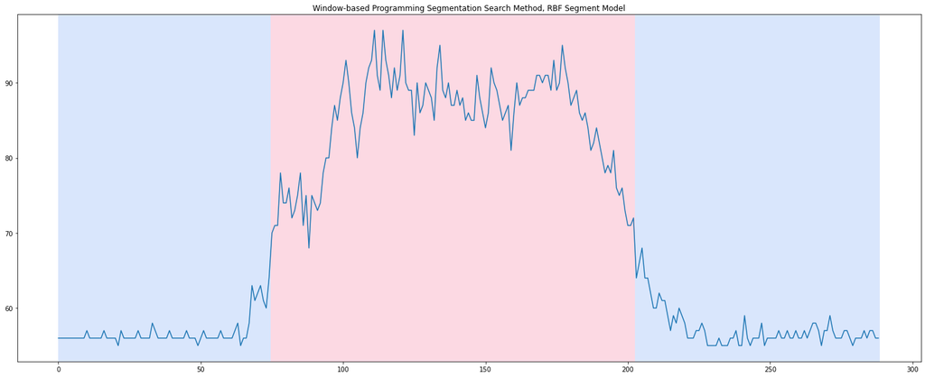

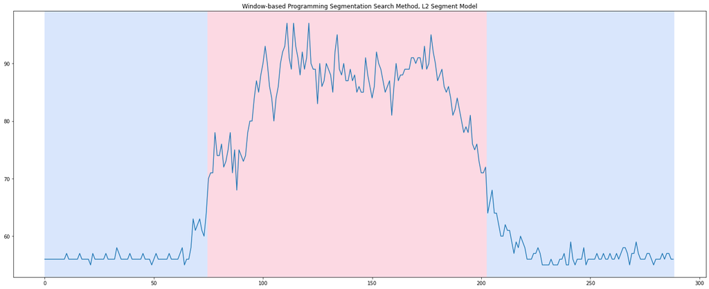

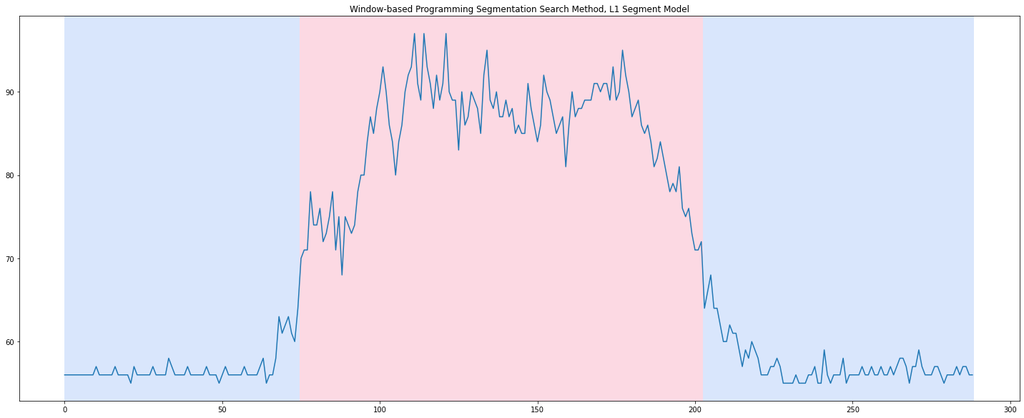

## Endpoints

### Analysis

The analysis endpoint takes a passed-in set of WiFi connection data and analyzes it on aggregate in order to suggest a scheduled start time and end time for resources on each day of the week, including Saturday and Sunday. In its approach, each of the 11 change point detection models described above are utilized to estimate a number of start times and end times for each date in the passed-in dataset. The 10th percentile is calculated from the large resulting list of determined start times for each day, and the 90th percentile is calculated from the resulting list of determined end times for each day. This provides the user with an ideal start and end time for each day of the week, covering 90% of instances of that day of the week based on historical data and excluding any outliers that arise in change point detection.

| Start of Day Timestamps (Ordered) | End of Day Timestamps (Ordered) |
| --- | --- |
| 5:04am | ... |
| 6:15am | 6:55pm |
| 6:17am | **7:00pm** |
| **6:20am** | 7:02pm |
| 6:25am | 7:05pm |
| ... | 7:27pm |

### Prediction

The prediction endpoint takes a passed-in set of WiFi connection data as well as a specific future date and suggests a scheduled start time and end time for resources on that specific date. In order to do so, it uses Facebook's [Prophet](https://facebook.github.io/prophet/) forecasting library to project WiFi connection data for the specified date, taking advantage of the library's ability to forecast cyclical time series with resiliency to holidays. Thereafter, the change point detection and percentile calculation described under analysis above is applied to the projected trend for the date in question and the 10th percentile of projected start times as well as 90th percentile of projected end times from the 11 models is returned as output.

[figure not shown]

## Download

To download and use ORB, please visit the GitHub repository at https://github.com/cweyandt/orb.

## Creators

[figure not shown]

**Ryan Belfer**, Business Analyst at National Association of Insurance Commissioners

[figure not shown]

**Clayton Monis**, Senior Market Research Analyst at Guidepoint

[figure not shown]

**Laura Treider**, DRAM Product Yield Enhancement Engineer at Micron Technology

[figure not shown]

**Chris Weyandt**, Ongoing Commissioning Team Leader and Energy Management Engineer at Lawrence Berkeley National Laboratory